# Couverture vaccinale antirougeoleuse des enfants de moins de 5 ans et caractéristiques des femmes de 15 à 49 ans en République Démocratique du Congo (2013-2014)

Wilfried Nlandu Tembele

2025-09-05

# 1 Introduction

La République Démocratique du Congo (RDC) fait face à d’importants défis de santé maternelle et infantile, avec une mortalité néonatale et infanto-juvénile encore élevée. La vaccination infantile constitue un indicateur clé de la santé publique et de la performance du système de soins. En RDC, les inégalités socio-démographiques peuvent influencer l’accès aux services de vaccination. L’Enquête Démographique et de Santé (EDS 2013–2014) met à disposition des données nationales représentatives collectées auprès des femmes de 15 à 49 ans. L’analyse de ces données permet d’examiner la couverture vaccinale déclarée par les mères et d’identifier les facteurs maternels, familiaux et contextuels qui y sont associés. Ce projet voudrait donc répondre à la question de rechercehe ci-après: *Quels sont les caractéristiques socio-démographiques maternelles associées à la vaccination des enfants rapportée par les femmes âgées de 15 à 49 ans en RDC, selon l’EDS 2013–2014?*

## 1.1 Objectifs de l’analyse

### 1.1.1 Objectif général

Identifier les caractéristiques des mères associées à la vaccination des enfants tel que rapporté par les femmes de 15–49 ans à partir du fichier IR de l’EDS 2013–2014.

### 1.1.2 Objectifs spécifiques

- Décrire les caractéristiques socio-démographiques des femmes
- Estimer la proportion d’enfants ayant reçu les vaccins de base selon les réponses des mères.
- Identifier les caractéristiques maternelles associées à la vaccination des enfants

# 2 Méthodologie

Il s’agit d’une analyse transversale menée en RDC utilisant les données de l’enquête Démogragraphique et santé de l’année 2013-2014. Les données individuelles des femmes âgées de 15 à 49 ans ont été utilisées pour mésurer la couverture vaccinale des enfants en VAR.

les poplutaions d’étude a concerné les femmes âgées de 15 à 49 ans ayant au moins un enfant et les enfants de moins de 5 ans avec des donnés sur la vaccination renseignées. L’étude a inclus 68325 enfants.

Les mères n’ayant pas d’enfant ont été rétirées des analyses.

Les variables retenues pour ces analyses sont les suivantes : `age_exact_mere`, `groupe_age` , `province`,`milieu_residence` , `niveau_education` , `statut_matrimonial` pour les mères et la `vaccination_rougeole`, `age_enfants` pour les enfants.

Des analyses descriptives ont été réalisées. Les résultats en proportions sont présentés sous forme des tableaux et graphiques.

# 3 Résultats des analyses

## 3.1 Description de la population d’étude

| age in 5-year groups | N | pourcentage |
| --- | --- | --- |
| 15-19 | 2102 | 3.1 |
| 20-24 | 8300 | 12.1 |
| 25-29 | 14592 | 21.4 |
| 30-34 | 13247 | 19.4 |
| 35-39 | 13036 | 19.1 |
| 40-44 | 9516 | 13.9 |
| 45-49 | 7532 | 11.0 |

La majorité des enquêtées sont âgées de 25-29 ans (21,4%). L’âge moyen des mères enquêtées est de 33.2 ± 8.2 ans..

## 3.2 Couverture vaccinale des enfants selon les caractéristiques socio-démographiques maternelles

### 3.2.1 Niveau d’éducation des mères

Proportion d’enfants vaccinés (%) selon le niveau d'éducation des mères

| highest educational level | Effectif | Enfants vaccinés | Proportion vaccinés (%) |
| --- | --- | --- | --- |
| no education | 15,422 | 1,948 | 12.6 |
| primary | 30,591 | 4,438 | 14.5 |
| secondary | 21,546 | 3,812 | 17.7 |
| higher | 766 | 168 | 21.9 |

*Interprétation* : la couverture vaccinale augmente avec le niveau d’éducation de la mère. Les femmes ayant un niveau supérieur font davantage vacciner leurs enfants (21,9%), tandis que celles sans niveau d’éducation présentent la couverture la plus faible (12,6%).

### 3.2.2 Province de résidence des mères

Le graphique ci-après montre la distribution de la coverture vaccinale en VAR par province. Les provinces les mieux couvertes sont le Sud-Kivu, le Nord-Kivu et Kinshasa (18,1–18,9%). Les provinces les moins couvertes sont le Kasai-Oriental, Maniema et le Katanga (11,7–12,8%).

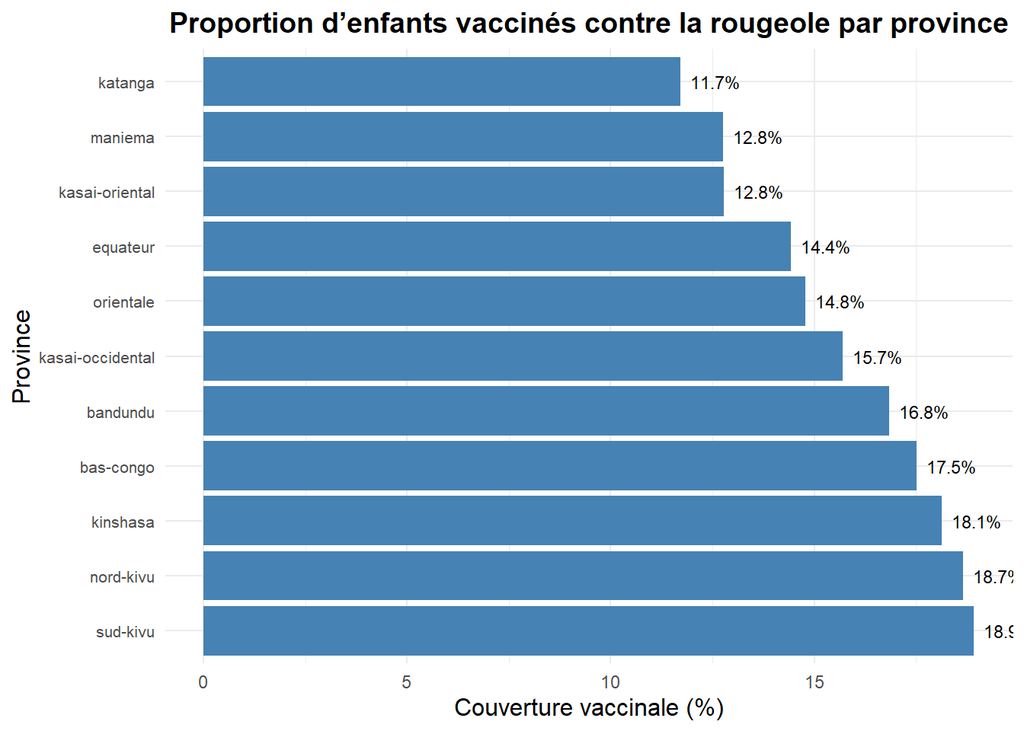

### 3.2.4 Milieu de résidence

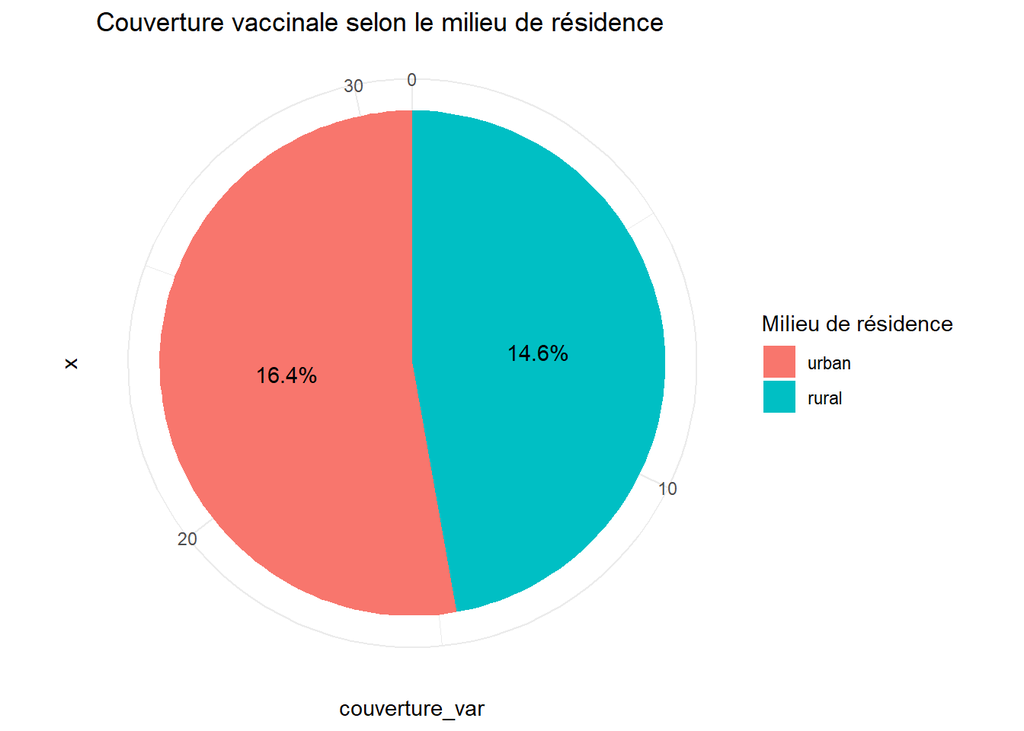

### 3.2.5 Statut matrimonial des mères

Les enfants de mères vivant seules (non en union) ont la couverture la plus élevée (24,4%), suivis des enfants dont les mères vivent avec un partenaire (17,1%). Les enfants de mères veuves présentent la couverture la plus faible (7,3%).

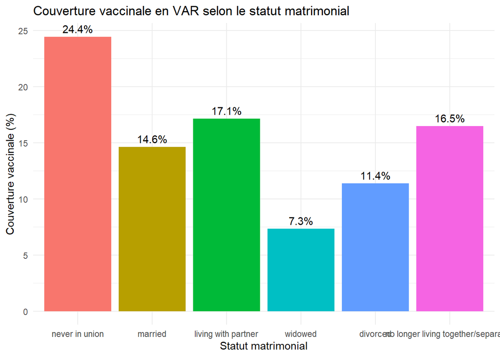

# 4 Conclusion

Ces résultats soulignent la nécessité d’interventions ciblées, notamment :

Globalement, ces mesures sont essentielles pour atteindre une couverture vaccinale optimale et réduire la mortalité infantile en RDC.

# 5 Référence

- Enquête Démographique et de Santé (EDS), République Démocratique du Congo, 2013-2014.